# Coding Assignment 1: Restaurant Sales and Daily Maximum Temperature

Author

Seth Johnson and Rachel Wiggins

Published

September 29, 2026

## Purpose

The purpose of this assignment is to give you an opportunity to apply many of the data assembly concepts that you have learned about in this course.

### Objectives

The main objective of this assignment is to explore whether restaurant sales are associated with daily maximum temperatures. However, the data come from different data frames that need to be restructured so that the data in them can be joined together.

- Work with your teammates to complete the tasks.
- Use several data assembly tasks, including those listed below:
  - Reading in data from Parquet files
  - Dealing with rows that have missing values
  - Reshaping data frames
  - Creating new columns in a data frame
  - Joining data frames
- Perform some initial exploration of the data in a data frame.
- Practice using `tidyverse` functions to clean, reshape, summarize, join, and visualize data.

### Task

Work with your assigned team to complete this coding assignment using **R, Quarto, and tidyverse**. Your goal is to explore whether restaurant sales are associated with daily maximum temperatures by cleaning, reshaping, and joining two datasets:

- `ities.parquet`
- `max_temp.parquet`

Download both Parquet files from Canvas and save them in the same folder as your Quarto (`.qmd`) file.

Begin by creating a new Quarto document (`.qmd`) in RStudio or Positron. Follow the step-by-step instructions to import data, handle missing values, reshape data frames, and generate summary statistics. You will also create new columns, join datasets, and produce visualizations to explore relationships between variables.

Once you have completed all required tasks, restart your R session, render the entire document, and make sure the HTML file is created without errors.

#### Quick Render Check

Run the code below and render your Quarto document.  
If the plot appears in the HTML file, your document is rendering R output correctly.

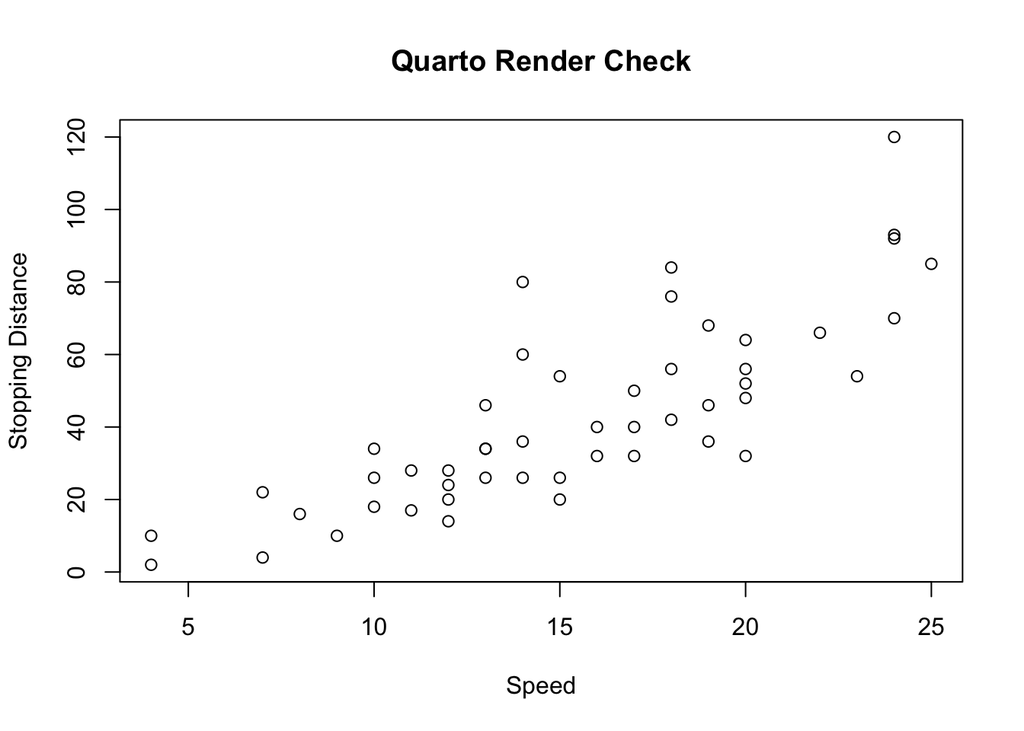

```r
plot(
  cars,
  main = "Quarto Render Check",
  xlab = "Speed",
  ylab = "Stopping Distance"
)
```

### Assignment Instructions

#### 1. (2 point) Load the packages

Load the R packages that you will use in the document.

Use:

- `tidyverse` for data wrangling and visualization
- `arrow` for reading Parquet files

```r
library(tidyverse)
library(arrow)
```

#### 2. (4 points) Load the restaurant data

Load the data from `ities.parquet` into a data frame named **dfi**.

Use `read_parquet()` from the `arrow` package.

Display the structure and the first five rows of **dfi**.

```r
dfi <- read_parquet("ities.parquet")
dim(dfi) # for the structure, will output rows then columns
```

```
[1] 438151     13
```

```r
head(dfi, 5)
```

```
# A tibble: 5 × 13
  Date      OperationType CashierName  LineItem Department Category RegisterName
  <chr>     <chr>         <chr>        <chr>    <chr>      <chr>    <chr>
1 7/18/2016 SALE          Wallace Kui… Salmon … Entrees    Salmon … RT149
2 7/18/2016 SALE          Wallace Kui… Fountai… Beverage   Fountain RT149
3 7/18/2016 SALE          Wallace Kui… Beef an… Kabobs     Beef     RT149
4 7/18/2016 SALE          Wallace Kui… Salmon … Salad      general  RT149
5 7/18/2016 SALE          Wallace Kui… Salmon … Salad      general  RT149
# ℹ 6 more variables: StoreNumber <chr>, TransactionNumber <chr>,
#   CustomerCode <chr>, Price <dbl>, Quantity <int>, TotalDue <dbl>
```

#### 3. (4 points) Load the weather data

Load the data from `max_temp.parquet` into a data frame named **dfw**.

Use `read_parquet()` from the `arrow` package.

Display the structure and the first five rows of **dfw**.

```r
dfw <- read_parquet("max_temp.parquet")
dim(dfw)
```

```
[1] 52  9
```

```r
head(dfw, 5)
```

```
# A tibble: 5 × 9
   Week Monday Tuesday Wednesday Thursday Friday Saturday Sunday WeekStarting
  <int>  <dbl>   <dbl>     <dbl>    <dbl>  <dbl>    <dbl>  <dbl> <chr>
1     1   46.9    45.0      41       45.0   59       57.0   57.0 1/3/2016
2     2   48.9    46.0      46.0     46.9   51.1     42.1   48.9 1/10/2016
3     3   48.0    52.0      53.1     55.0   50       51.1   50   1/17/2016
4     4   34.0    41        51.1     46.9   55.9     51.1   36.0 1/24/2016
5     5   51.1    60.1      57.9     51.1   41       48.0   52.0 1/31/2016
```

#### 4. (8 points) Check and convert data types

Using any appropriate commands, make any necessary data type conversions to columns in **dfi** and/or **dfw**.

When appropriate, use tidyverse functions such as `mutate()` together with functions for converting dates, numbers, or character variables.

Include code that displays the updated structure of the data frames to verify that the data type conversions, if any, worked.

Below the output, comment on why you did or did not make data type conversions.

You may want to come back to this task and update it once you start working on the subsequent tasks.

```r
# The date format here is not very effective for analysis. I will update it to convert it to yy-mm-dd

library(lubridate)

dfw <- dfw %>%
  mutate(WeekStarting = mdy(WeekStarting))

head(dfw, 5)
```

```
# A tibble: 5 × 9
   Week Monday Tuesday Wednesday Thursday Friday Saturday Sunday WeekStarting
  <int>  <dbl>   <dbl>     <dbl>    <dbl>  <dbl>    <dbl>  <dbl> <date>
1     1   46.9    45.0      41       45.0   59       57.0   57.0 2016-01-03
2     2   48.9    46.0      46.0     46.9   51.1     42.1   48.9 2016-01-10
3     3   48.0    52.0      53.1     55.0   50       51.1   50   2016-01-17
4     4   34.0    41        51.1     46.9   55.9     51.1   36.0 2016-01-24
5     5   51.1    60.1      57.9     51.1   41       48.0   52.0 2016-01-31
```

```r
#doing the same thing for dfi
dfi <-  dfi %>%
  mutate(Date = mdy(Date))

head(dfi, 5)
```

```
# A tibble: 5 × 13
  Date       OperationType CashierName LineItem Department Category RegisterName
  <date>     <chr>         <chr>       <chr>    <chr>      <chr>    <chr>
1 2016-07-18 SALE          Wallace Ku… Salmon … Entrees    Salmon … RT149
2 2016-07-18 SALE          Wallace Ku… Fountai… Beverage   Fountain RT149
3 2016-07-18 SALE          Wallace Ku… Beef an… Kabobs     Beef     RT149
4 2016-07-18 SALE          Wallace Ku… Salmon … Salad      general  RT149
5 2016-07-18 SALE          Wallace Ku… Salmon … Salad      general  RT149
# ℹ 6 more variables: StoreNumber <chr>, TransactionNumber <chr>,
#   CustomerCode <chr>, Price <dbl>, Quantity <int>, TotalDue <dbl>
```

**Comment:** From looking at the first five rows of each data frame, the date was give in a chr format. chr is not sufficient for analysis, so I knew if we were to use dates in any analysis this will need to be changed. I updated the format using a function with the mutate command to give an R object of the date. I did this with both data frames. Upon first glance this was the only change I thought would be necessary at this time.

#### 5. (2 point) Display summary statistics

Display summary statistics for all columns of both data frames.

```r
summary(dfi)
```

```
      Date              OperationType       CashierName          LineItem
 Min.   :2014-01-04   Length   :438151   Length   :438151   Length   :438151
 1st Qu.:2014-09-11   N.unique :     2   N.unique :    56   N.unique :    68
 Median :2015-06-26   N.blank  :     0   N.blank  :     0   N.blank  :     0
 Mean   :2015-07-11   Min.nchar:     4   Min.nchar:     8   Min.nchar:     4
 3rd Qu.:2016-04-26   Max.nchar:     6   Max.nchar:    17   Max.nchar:    39
 Max.   :2017-04-05

     Department          Category         RegisterName       StoreNumber
 Length   :438151   Length   :438151   Length   :438151   Length   :438151
 N.unique :     9   N.unique :    21   N.unique :    12   N.unique :    70
 N.blank  :     0   N.blank  :     0   N.blank  :     0   N.blank  :     0
 Min.nchar:     4   Min.nchar:     4   Min.nchar:     5   Min.nchar:    10
 Max.nchar:    10   Max.nchar:    31   Max.nchar:     5   Max.nchar:    10


 TransactionNumber     CustomerCode        Price             Quantity
 Length   :438151   Length   :438151   Min.   :-5740.51   Min.   :  1.000
 N.unique :161058   N.unique :  9110   1st Qu.:    4.50   1st Qu.:  1.000
 N.blank  :     0   N.blank  :     0   Median :   11.29   Median :  1.000
 Min.nchar:     7   Min.nchar:    10   Mean   :   14.36   Mean   :  1.177
 Max.nchar:    13   Max.nchar:    11   3rd Qu.:   14.68   3rd Qu.:  1.000
                                       Max.   :21449.97   Max.   :815.000
                                       NAs    :12
    TotalDue
 Min.   :-5740.51
 1st Qu.:    4.50
 Median :   11.80
 Mean   :   15.26
 3rd Qu.:   15.04
 Max.   :21449.97
 NAs    :12
```

```r
summary(dfw)
```

```
      Week           Monday          Tuesday         Wednesday
 Min.   : 1.00   Min.   : 33.98   Min.   : 28.94   Min.   : 30.92
 1st Qu.:13.75   1st Qu.: 48.92   1st Qu.: 50.00   1st Qu.: 51.98
 Median :26.50   Median : 67.46   Median : 68.00   Median : 65.93
 Mean   :26.50   Mean   : 68.29   Mean   : 68.12   Mean   : 69.19
 3rd Qu.:39.25   3rd Qu.: 88.30   3rd Qu.: 87.58   3rd Qu.: 89.28
 Max.   :52.00   Max.   :100.94   Max.   :100.94   Max.   :102.02
    Thursday          Friday          Saturday          Sunday
 Min.   : 30.92   Min.   : 33.08   Min.   : 28.94   Min.   : 33.98
 1st Qu.: 50.54   1st Qu.: 55.45   1st Qu.: 53.96   1st Qu.: 51.98
 Median : 67.01   Median : 65.03   Median : 68.54   Median : 70.52
 Mean   : 69.41   Mean   : 70.68   Mean   : 70.58   Mean   : 69.25
 3rd Qu.: 89.56   3rd Qu.: 91.27   3rd Qu.: 89.56   3rd Qu.: 89.96
 Max.   :100.94   Max.   :104.00   Max.   :102.02   Max.   :102.92
  WeekStarting
 Min.   :2016-01-03
 1st Qu.:2016-04-01
 Median :2016-06-29
 Mean   :2016-06-29
 3rd Qu.:2016-09-26
 Max.   :2016-12-25
```

#### 6. (6 points) Identify and handle missing values

Include code that displays the count of missing values in each column of **dfi**.

Note that only a small number of rows are affected, and not every column contains missing values.

Use tidyverse functions such as `summarise()` and `across()` where appropriate.

Choose to remove the rows with missing values or impute the missing values, and then use appropriate commands to complete that process.

Use code to display evidence that it worked, such as summarizing the missing values again.

Defend that choice in 1–2 sentences for each column with missing values.

```r
library(dplyr)

# finding rows with missing values in dfi
na_counts_dplyr <- dfi %>%
  summarise_all(~ sum(is.na(.)))


print(na_counts_dplyr)
```

```
# A tibble: 1 × 13
   Date OperationType CashierName LineItem Department Category RegisterName
  <int>         <int>       <int>    <int>      <int>    <int>        <int>
1     0             0           0        0          0        0            0
# ℹ 6 more variables: StoreNumber <int>, TransactionNumber <int>,
#   CustomerCode <int>, Price <int>, Quantity <int>, TotalDue <int>
```

```r
# Display rows where columns contain NA
dfi_missing <- dfi %>%
  filter(if_any(everything(), is.na))

print(dfi_missing)
```

```
# A tibble: 12 × 13
   Date       OperationType CashierName    LineItem          Department Category
   <date>     <chr>         <chr>          <chr>             <chr>      <chr>
 1 2016-07-18 SALE          Wallace Kuiper Chicken and Onio… Kabobs     Chicken
 2 2016-07-18 SALE          Wallace Kuiper Chicken and Onio… Kabobs     Chicken
 3 2016-07-18 SALE          Wallace Kuiper Chicken and Onio… Kabobs     Chicken
 4 2016-07-18 SALE          Wallace Kuiper Chicken and Onio… Kabobs     Chicken
 5 2016-07-16 SALE          Karen Castro   Chicken and Onio… Kabobs     Chicken
 6 2016-07-16 SALE          Karen Castro   Chicken and Onio… Kabobs     Chicken
 7 2016-07-16 SALE          Karen Castro   Chicken and Onio… Kabobs     Chicken
 8 2016-07-13 SALE          Wallace Kuiper Beef and Squash … Kabobs     Beef
 9 2016-07-13 SALE          Wallace Kuiper Beef and Squash … Kabobs     Beef
10 2016-07-13 SALE          Wallace Kuiper Beef and Squash … Kabobs     Beef
11 2016-07-13 SALE          Wallace Kuiper Beef and Squash … Kabobs     Beef
12 2016-07-13 SALE          Wallace Kuiper Beef and Squash … Kabobs     Beef
# ℹ 7 more variables: RegisterName <chr>, StoreNumber <chr>,
#   TransactionNumber <chr>, CustomerCode <chr>, Price <dbl>, Quantity <int>,
#   TotalDue <dbl>
```

```r
#missing prices come from Price and TotalDue columns

#finding price values of Chicken and Onion Kabob and Beef and Squash Kabob

chick_onion <- dfi %>%
  filter(LineItem == "Chicken and Onion Kabob")

head(chick_onion)
```

```
# A tibble: 6 × 13
  Date       OperationType CashierName LineItem Department Category RegisterName
  <date>     <chr>         <chr>       <chr>    <chr>      <chr>    <chr>
1 2016-07-18 SALE          Wallace Ku… Chicken… Kabobs     Chicken  RT149
2 2016-07-18 SALE          Wallace Ku… Chicken… Kabobs     Chicken  RT149
3 2016-07-18 SALE          Wallace Ku… Chicken… Kabobs     Chicken  RT149
4 2016-07-18 SALE          Wallace Ku… Chicken… Kabobs     Chicken  RT149
5 2016-07-18 SALE          Carla Knot… Chicken… Kabobs     Chicken  RT151
6 2016-07-18 SALE          Wallace Ku… Chicken… Kabobs     Chicken  RT149
# ℹ 6 more variables: StoreNumber <chr>, TransactionNumber <chr>,
#   CustomerCode <chr>, Price <dbl>, Quantity <int>, TotalDue <dbl>
```

```r
#price is 14.68 for Chicken and Onion Kabob

#finding price values of Beef and Squash Kabob

beef_squash <- dfi %>%
  filter(LineItem == "Beef and Squash Kabob")

head(beef_squash)
```

```
# A tibble: 6 × 13
  Date       OperationType CashierName LineItem Department Category RegisterName
  <date>     <chr>         <chr>       <chr>    <chr>      <chr>    <chr>
1 2016-07-18 SALE          Wallace Ku… Beef an… Kabobs     Beef     RT149
2 2016-07-18 SALE          Wallace Ku… Beef an… Kabobs     Beef     RT149
3 2016-07-18 SALE          Wallace Ku… Beef an… Kabobs     Beef     RT149
4 2016-07-18 SALE          Wallace Ku… Beef an… Kabobs     Beef     RT149
5 2016-07-18 SALE          Wallace Ku… Beef an… Kabobs     Beef     RT149
6 2016-07-18 SALE          Wallace Ku… Beef an… Kabobs     Beef     RT149
# ℹ 6 more variables: StoreNumber <chr>, TransactionNumber <chr>,
#   CustomerCode <chr>, Price <dbl>, Quantity <int>, TotalDue <dbl>
```

```r
#price is 12.02 for Beef and Squash Kabob

#replacing Price values using case_when, TRUE leaves other values untouched
dfi_cleaned <- dfi %>%
  mutate(Price = case_when(
    Category == "Chicken" & is.na(Price) ~ 14.68,
    Category == "Beef" & is.na(Price) ~ 12.02,
    TRUE ~ Price
  ))

#replacing TotalDue with calculated values from Price and Quantity
dfi_real_clean <- dfi_cleaned %>%
  mutate(TotalDue = case_when(
    Category == "Chicken" & is.na(TotalDue) ~ 14.68 * Quantity,
    Category == "Beef" & is.na(TotalDue) ~ 12.02 * Quantity,
    TRUE ~ Price
  ))

#rechecking for missing values
na_counts_dplyr <- dfi %>%
  summarise_all(~ sum(is.na(.)))

summary(dfi_real_clean)
```

```
      Date              OperationType       CashierName          LineItem
 Min.   :2014-01-04   Length   :438151   Length   :438151   Length   :438151
 1st Qu.:2014-09-11   N.unique :     2   N.unique :    56   N.unique :    68
 Median :2015-06-26   N.blank  :     0   N.blank  :     0   N.blank  :     0
 Mean   :2015-07-11   Min.nchar:     4   Min.nchar:     8   Min.nchar:     4
 3rd Qu.:2016-04-26   Max.nchar:     6   Max.nchar:    17   Max.nchar:    39
 Max.   :2017-04-05
     Department          Category         RegisterName       StoreNumber
 Length   :438151   Length   :438151   Length   :438151   Length   :438151
 N.unique :     9   N.unique :    21   N.unique :    12   N.unique :    70
 N.blank  :     0   N.blank  :     0   N.blank  :     0   N.blank  :     0
 Min.nchar:     4   Min.nchar:     4   Min.nchar:     5   Min.nchar:    10
 Max.nchar:    10   Max.nchar:    31   Max.nchar:     5   Max.nchar:    10

 TransactionNumber     CustomerCode        Price             Quantity
 Length   :438151   Length   :438151   Min.   :-5740.51   Min.   :  1.000
 N.unique :161058   N.unique :  9110   1st Qu.:    4.50   1st Qu.:  1.000
 N.blank  :     0   N.blank  :     0   Median :   11.29   Median :  1.000
 Min.nchar:     7   Min.nchar:    10   Mean   :   14.36   Mean   :  1.177
 Max.nchar:    13   Max.nchar:    11   3rd Qu.:   14.68   3rd Qu.:  1.000
                                       Max.   :21449.97   Max.   :815.000
    TotalDue
 Min.   :-5740.51
 1st Qu.:    4.50
 Median :   11.29
 Mean   :   14.36
 3rd Qu.:   14.68
 Max.   :21449.97
```

#### 7. (8 points) Aggregate the restaurant data to the daily level

We need to prepare **dfi** and **dfw** so that we can join them together.

To do so, we want to aggregate the restaurant data at the daily level.

Create a new data frame named **dfid** by aggregating **dfi** at the daily level.

The data frame **dfid** must contain the date column and the columns `Quantity` and `TotalDue` from **dfi**, summarized at the daily level.

Use tidyverse functions such as:

- `group_by()`
- `summarise()`

Include code that displays the first 10 rows of **dfid** to verify that it worked.

In 1–2 sentences, defend the choice of the summary measure (sum, mean, or another measure) used to aggregate the values in each column.

```r
dfid <- dfi_real_clean %>%
  group_by(Date) %>%
  summarize(
    Quantity= sum(Quantity, na.rm = TRUE),
    TotalDue = sum(TotalDue, na.rm = TRUE)
    )

head(dfid, n=10)
```

```
# A tibble: 10 × 3
   Date       Quantity TotalDue
   <date>        <int>    <dbl>
 1 2014-01-04      593    6478.
 2 2014-01-06      345    7317.
 3 2014-01-07      410    4983.
 4 2014-01-08      413    4018.
 5 2014-01-09      420    5119.
 6 2014-01-10      656    6801.
 7 2014-01-11      695    7148.
 8 2014-01-13      270    2991.
 9 2014-01-14      404    4445.
10 2014-01-15      632    5179.
```

**Explanation:**

Aggregating by sum seemed like a good way to visualize differences in how much money was brought in per day. Taking the average would give the average quantity and total due per transaction, and that doesn’t seem to be what we are interested in.

#### 8. (4 points) Reshape the weather data

Create a new data frame named **dfwd** by converting **dfw** from a wide format to a long format.

The names of the seven columns, Monday through Sunday, should be stored in a new column named `day`, and the values from those seven columns should be stored in a new column named `max_temp`.

Use the tidyverse function `pivot_longer()`.

Include code that displays the first 10 rows of **dfwd** to verify that the conversion worked.

```r
# converting to long format
dfwd <- dfw %>%
  pivot_longer(cols = Monday:Sunday, names_to = "day", values_to = "max_temp")


head(dfwd, n=10)
```

```
# A tibble: 10 × 4
    Week WeekStarting day       max_temp
   <int> <date>       <chr>        <dbl>
 1     1 2016-01-03   Monday        46.9
 2     1 2016-01-03   Tuesday       45.0
 3     1 2016-01-03   Wednesday     41
 4     1 2016-01-03   Thursday      45.0
 5     1 2016-01-03   Friday        59
 6     1 2016-01-03   Saturday      57.0
 7     1 2016-01-03   Sunday        57.0
 8     2 2016-01-10   Monday        48.9
 9     2 2016-01-10   Tuesday       46.0
10     2 2016-01-10   Wednesday     46.0
```

#### 9. (8 points) Create a Date column

Update the **dfwd** data frame by adding a column named `Date` that corresponds to the value in the `day` column.

For example, if the `WeekStarting` value is `2016-01-03`, then the value in the `Date` column for the Monday that comes after `2016-01-03` should be `2016-01-04`.

Use tidyverse functions such as `mutate()` and `case_when()` where appropriate.

Arrange **dfwd** in ascending order of `Date` and include code to display the first 10 rows to verify that it worked.

Beneath the output, comment on how you know that the creation of the `Date` column worked.

```r
# Calcualting dates
dfwd <- dfwd %>%
  mutate(Date = case_when(
    day == "Sunday" ~ WeekStarting,
    day == "Monday" ~ WeekStarting + 1,
    day == "Tuesday" ~ WeekStarting + 2,
    day == "Wednesday" ~ WeekStarting + 3,
    day == "Thursday" ~ WeekStarting + 4,
    day == "Friday" ~ WeekStarting + 5,
    day == "Saturday" ~ WeekStarting + 6,
    TRUE ~ as.Date(NA)
  ))

dfwd <- dfwd %>%
   arrange(Date)

head(dfwd, n=10)
```

```
# A tibble: 10 × 5
    Week WeekStarting day       max_temp Date
   <int> <date>       <chr>        <dbl> <date>
 1     1 2016-01-03   Sunday        57.0 2016-01-03
 2     1 2016-01-03   Monday        46.9 2016-01-04
 3     1 2016-01-03   Tuesday       45.0 2016-01-05
 4     1 2016-01-03   Wednesday     41   2016-01-06
 5     1 2016-01-03   Thursday      45.0 2016-01-07
 6     1 2016-01-03   Friday        59   2016-01-08
 7     1 2016-01-03   Saturday      57.0 2016-01-09
 8     2 2016-01-10   Sunday        48.9 2016-01-10
 9     2 2016-01-10   Monday        48.9 2016-01-11
10     2 2016-01-10   Tuesday       46.0 2016-01-12
```

#### 10. (4 points) Join the two data frames

Join the data frames **dfid** and **dfwd** into one data frame named **df** such that only the rows that are in both **dfid** and **dfwd** are included in **df**.

Use the tidyverse function `inner_join()`.

Arrange **df** in ascending order of `Date`.

Then include code that displays something to show that the join worked.

Briefly identify how that output helps you know that the join worked.

The restaurant data and the weather data do not cover the same span of dates, so **df** will have far fewer rows than **dfid**. As a check on your work, **df** should contain **311 rows**. If your row count differs, revisit your date conversions in Task 4 and your `Date` column in Task 9.

In 1–2 sentences, explain why an inner join is the appropriate choice here, and identify what would have been different had you used `left_join()` instead.

```r
# inner join by date column
df <- inner_join(dfid, dfwd, by = "Date")

df <- df %>%
  arrange(Date)

dim(df)
```

```
[1] 311   7
```

```r
head(df)
```

```
# A tibble: 6 × 7
  Date       Quantity TotalDue  Week WeekStarting day       max_temp
  <date>        <int>    <dbl> <int> <date>       <chr>        <dbl>
1 2016-01-05      304    3178.     1 2016-01-03   Tuesday       45.0
2 2016-01-06      357    3463.     1 2016-01-03   Wednesday     41
3 2016-01-07      389    5750.     1 2016-01-03   Thursday      45.0
4 2016-01-08      583    5952.     1 2016-01-03   Friday        59
5 2016-01-09      605    5810.     1 2016-01-03   Saturday      57.0
6 2016-01-11      366    3816.     2 2016-01-10   Monday        48.9
```

#### 11. (8 points) Create scatterplots

Use `ggplot2` to create the three scatterplots described below.

Make sure each plot has an appropriate title and clearly labeled axes.

##### A. Maximum temperature and TotalDue

Create a scatterplot with:

- `max_temp` on the x-axis
- `TotalDue` on the y-axis

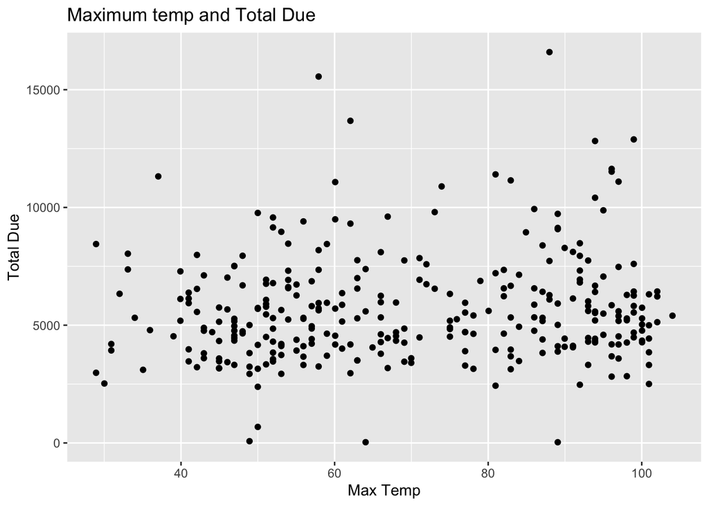

Figure 1: Daily maximum temperature and total amount due

```r
# Plotting max temp and total due
library(ggplot2)

ggplot(df, aes(x = max_temp, y = TotalDue)) +
  geom_point() +
  labs(
    title = "Maximum temp and Total Due",
    x = "Max Temp",
    y = "Total Due"
  )
```

##### B. Maximum temperature and Quantity

Create a scatterplot with:

- `max_temp` on the x-axis
- `Quantity` on the y-axis

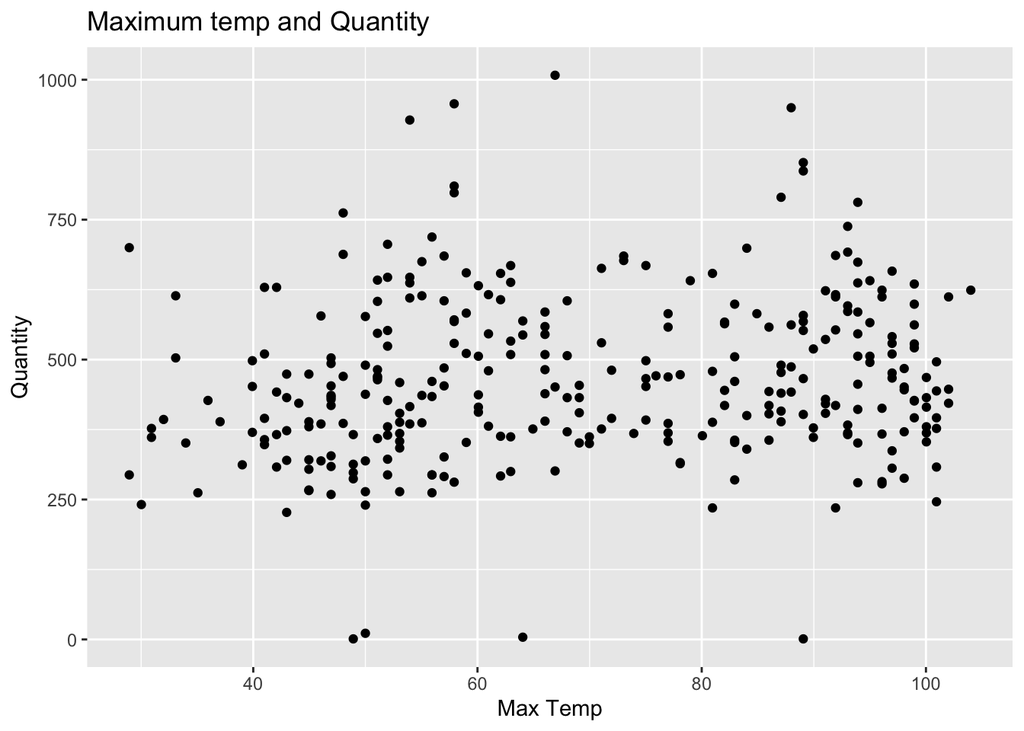

Figure 2: Daily maximum temperature and quantity sold

```r
# plotting max temp and quantity sold
ggplot(df, aes(x = max_temp, y = Quantity)) +
  geom_point() +
  labs(
    title = "Maximum temp and Quantity",
    x = "Max Temp",
    y = "Quantity"
  )
```

##### C. Quantity and TotalDue

Create a scatterplot with:

- `Quantity` on the x-axis
- `TotalDue` on the y-axis

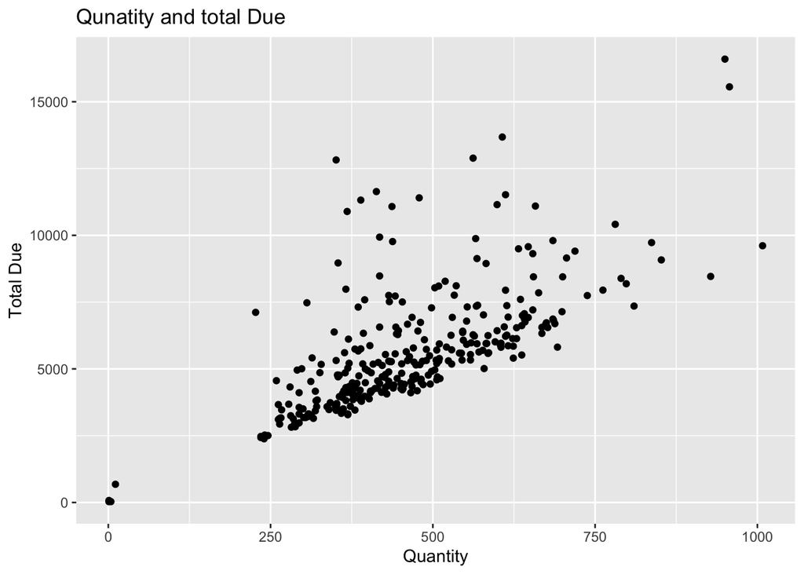

Figure 3: Quantity sold and total amount due

```r
# plotting quantity sold and total amount due
ggplot(df, aes(x = Quantity, y = TotalDue)) +
  geom_point() +
  labs(
    title = "Qunatity and total Due",
    x = "Quantity",
    y = "Total Due"
  )
```

Below the third scatterplot, identify whether there appears to be a relationship for each pair of variables:

- `max_temp` and `TotalDue`
- `max_temp` and `Quantity`
- `Quantity` and `TotalDue`

For each relationship, briefly describe the **direction**, **form**, and **strength** of the pattern you observe.

Remember that these are observational data, so the scatterplots can show an association but do not by themselves establish causation.

**Interpretation:**

The scatterplot of `max_temp` plotted against `TotalDue` appears to show data oriented horizontally, with fairly consistent variance, with an intercept just above 5000. The fact that the line is horizontal, the data homoscedastic, and that the errors don’t seem to demonstrate autocorrelation all seem to suggest that there is not a strong relationship between these two variables.

The situation appears to be similar for `max_temp` and `Quantity` where the data seems like it could again be adequately modeled with just a horizontal line representing the mean. The quantity does not seem to vary as X (max_temp) varies.

Because the plots of max_temp`and`TotalDue`and`max_temp`and`Quantity`showed similar shape and variance, it is perhaps unsurprising that`Quantity`and`TotalDue`appear to be positively associated. The data seems like it could be modeled here with a straight line with a positive slope. Shapewise, the data is gathered downward toward the place a regression line looks like it should go, with the variance stretching only upward. This suggests the relationship between quantity and total due, which, for each product separately would be perfectly linear (total due is an exact number based on quantity.) But this plot includes all products, which explains the variance of data that appears to be floating upwards off the line: some products are more expensive than others, and the more expensive ones are not purchased as often.

#### 12. (8 points) Reflection

Briefly answer each question in **1–2 sentences**.

**1. What did you do well on this assignment?** Seth - I thought I did well with getting familiar with R. It is pretty similar to python so I felt like it was pretty quick to pick up.

Rachel - I felt like I did a good job anticipating problems with manipulating the data in certain ways and was able to understand what we were being asked to do. Working with the R code itself also felt pretty easy and natural, although I’m more familiar with Python.

**2. What was the most challenging part of the assignment?** Seth - Getting data formatted in the correct way. I found I had to go back a couple of times and make some minor adjustments.

Rachel - The hardest thing was just the time consuming nature of looking up the syntax of the tidyverse library for various methods. Sometimes it took a while for me to understand the examples given in the documentation.

**3. What would have improved your experience with this assignment?** Seth - I thought this was a really good introduction to R. But I think it would have been cool to do some basics with linear regression. We have been doing that a lot in class so it would have been nice to see.

Rachel - I agree with Seth. Incorporating some OLS or other kinds of linear regressions would have been a good follow up to this assignment.

**4. What do you still need help with?** Seth - I am feeling pretty good with my coding ability and R familiarization, but I know my statistics knowledge is still a little rusty. I have been doing my own reviews.

Rachel - I’m not the greatest at keeping coding languages straight in my head, so I’m sure I’ll need to keep looking up specifics of how to code in R so I don’t accidentally incorporate some Python or C++.

#### 13. (3 point) Render and submit the document

Make sure to:

1. Save your Quarto document.
2. Restart your R session.
3. Render the entire document from beginning to end.
4. Confirm that the document renders without errors.
5. Submit both the `.qmd` file and the rendered `.html` file.

## Group Dynamics

1. Download the `ities.parquet` and `max_temp.parquet` files from Canvas and save them in the same folder on your computer.
2. Open RStudio or Positron and navigate to the folder where the data files are saved.
3. Create a new Quarto (`.qmd`) document in that folder.
4. Complete all required tasks using R and tidyverse.
5. Restart your R session and render the Quarto document.
6. Make sure that **one person in your group submits** both the `.qmd` and `.html` files on Canvas.

### Grading Criteria

Points will be awarded based on the point allocation listed above.

Points may also be deducted for items not explicitly listed, such as failure to submit the assignment on time or failure to submit a document that renders correctly.